# Risk Factor Analysis

## Outcome Variable

**Outcome Variable:** swasted

## Predictor Variables

**Intervention Variable:** nchldlt5

**Adjustment Set:**

- arm
- W_mage
- meducyrs
- feducyrs
- hhwealth_quart
- hfoodsec
- W_mhtcm
- W_nrooms
- W_parity
- impfloor
- impsan
- safeh20
- delta_W_mage
- delta_meducyrs
- delta_feducyrs
- delta_hhwealth_quart
- delta_hfoodsec
- delta_W_mhtcm
- delta_W_nrooms
- delta_W_parity
- delta_impfloor
- delta_impsan
- delta_safeh20

## Stratifying Variables

The analysis was stratified on these variable(s):

- agecat
- studyid
- country

## Data Summary

| agecat | studyid | country | nchldlt5 | swasted | n_cell | n |
| --- | --- | --- | --- | --- | --- | --- |
| Birth | ki1000108-IRC | INDIA | 1 | 0 | 59 | 245 |
| Birth | ki1000108-IRC | INDIA | 1 | 1 | 13 | 245 |
| Birth | ki1000108-IRC | INDIA | 2+ | 0 | 151 | 245 |
| Birth | ki1000108-IRC | INDIA | 2+ | 1 | 22 | 245 |
| Birth | ki1017093c-NIH-Crypto | BANGLADESH | 1 | 0 | 14 | 16 |
| Birth | ki1017093c-NIH-Crypto | BANGLADESH | 1 | 1 | 1 | 16 |
| Birth | ki1017093c-NIH-Crypto | BANGLADESH | 2+ | 0 | 1 | 16 |
| Birth | ki1017093c-NIH-Crypto | BANGLADESH | 2+ | 1 | 0 | 16 |
| Birth | kiGH5241-JiVitA-3 | BANGLADESH | 1 | 0 | 18434 | 19544 |
| Birth | kiGH5241-JiVitA-3 | BANGLADESH | 1 | 1 | 334 | 19544 |
| Birth | kiGH5241-JiVitA-3 | BANGLADESH | 2+ | 0 | 770 | 19544 |
| Birth | kiGH5241-JiVitA-3 | BANGLADESH | 2+ | 1 | 6 | 19544 |
| 6 months | ki1000108-IRC | INDIA | 1 | 0 | 83 | 289 |
| 6 months | ki1000108-IRC | INDIA | 1 | 1 | 5 | 289 |
| 6 months | ki1000108-IRC | INDIA | 2+ | 0 | 190 | 289 |
| 6 months | ki1000108-IRC | INDIA | 2+ | 1 | 11 | 289 |
| 6 months | ki1017093b-PROVIDE | BANGLADESH | 1 | 0 | 422 | 435 |
| 6 months | ki1017093b-PROVIDE | BANGLADESH | 1 | 1 | 4 | 435 |
| 6 months | ki1017093b-PROVIDE | BANGLADESH | 2+ | 0 | 8 | 435 |
| 6 months | ki1017093b-PROVIDE | BANGLADESH | 2+ | 1 | 1 | 435 |
| 6 months | ki1017093c-NIH-Crypto | BANGLADESH | 1 | 0 | 507 | 512 |
| 6 months | ki1017093c-NIH-Crypto | BANGLADESH | 1 | 1 | 0 | 512 |
| 6 months | ki1017093c-NIH-Crypto | BANGLADESH | 2+ | 0 | 5 | 512 |
| 6 months | ki1017093c-NIH-Crypto | BANGLADESH | 2+ | 1 | 0 | 512 |
| 6 months | ki1066203-TanzaniaChild2 | TANZANIA, UNITED REPUBLIC OF | 1 | 0 | 1382 | 1452 |
| 6 months | ki1066203-TanzaniaChild2 | TANZANIA, UNITED REPUBLIC OF | 1 | 1 | 8 | 1452 |
| 6 months | ki1066203-TanzaniaChild2 | TANZANIA, UNITED REPUBLIC OF | 2+ | 0 | 61 | 1452 |
| 6 months | ki1066203-TanzaniaChild2 | TANZANIA, UNITED REPUBLIC OF | 2+ | 1 | 1 | 1452 |
| 6 months | ki1148112-LCNI-5 | MALAWI | 1 | 0 | 390 | 453 |
| 6 months | ki1148112-LCNI-5 | MALAWI | 1 | 1 | 0 | 453 |
| 6 months | ki1148112-LCNI-5 | MALAWI | 2+ | 0 | 63 | 453 |
| 6 months | ki1148112-LCNI-5 | MALAWI | 2+ | 1 | 0 | 453 |
| 6 months | kiGH5241-JiVitA-3 | BANGLADESH | 1 | 0 | 21419 | 22430 |
| 6 months | kiGH5241-JiVitA-3 | BANGLADESH | 1 | 1 | 288 | 22430 |
| 6 months | kiGH5241-JiVitA-3 | BANGLADESH | 2+ | 0 | 707 | 22430 |
| 6 months | kiGH5241-JiVitA-3 | BANGLADESH | 2+ | 1 | 16 | 22430 |
| 24 months | ki1000108-IRC | INDIA | 1 | 0 | 86 | 290 |
| 24 months | ki1000108-IRC | INDIA | 1 | 1 | 3 | 290 |
| 24 months | ki1000108-IRC | INDIA | 2+ | 0 | 200 | 290 |
| 24 months | ki1000108-IRC | INDIA | 2+ | 1 | 1 | 290 |
| 24 months | ki1017093b-PROVIDE | BANGLADESH | 1 | 0 | 418 | 431 |
| 24 months | ki1017093b-PROVIDE | BANGLADESH | 1 | 1 | 5 | 431 |
| 24 months | ki1017093b-PROVIDE | BANGLADESH | 2+ | 0 | 8 | 431 |
| 24 months | ki1017093b-PROVIDE | BANGLADESH | 2+ | 1 | 0 | 431 |
| 24 months | ki1017093c-NIH-Crypto | BANGLADESH | 1 | 0 | 353 | 361 |
| 24 months | ki1017093c-NIH-Crypto | BANGLADESH | 1 | 1 | 4 | 361 |
| 24 months | ki1017093c-NIH-Crypto | BANGLADESH | 2+ | 0 | 4 | 361 |
| 24 months | ki1017093c-NIH-Crypto | BANGLADESH | 2+ | 1 | 0 | 361 |
| 24 months | ki1066203-TanzaniaChild2 | TANZANIA, UNITED REPUBLIC OF | 1 | 0 | 5 | 5 |
| 24 months | ki1066203-TanzaniaChild2 | TANZANIA, UNITED REPUBLIC OF | 1 | 1 | 0 | 5 |
| 24 months | ki1066203-TanzaniaChild2 | TANZANIA, UNITED REPUBLIC OF | 2+ | 0 | 0 | 5 |
| 24 months | ki1066203-TanzaniaChild2 | TANZANIA, UNITED REPUBLIC OF | 2+ | 1 | 0 | 5 |
| 24 months | ki1148112-LCNI-5 | MALAWI | 1 | 0 | 276 | 321 |
| 24 months | ki1148112-LCNI-5 | MALAWI | 1 | 1 | 1 | 321 |
| 24 months | ki1148112-LCNI-5 | MALAWI | 2+ | 0 | 44 | 321 |
| 24 months | ki1148112-LCNI-5 | MALAWI | 2+ | 1 | 0 | 321 |
| 24 months | kiGH5241-JiVitA-3 | BANGLADESH | 1 | 0 | 10379 | 11282 |
| 24 months | kiGH5241-JiVitA-3 | BANGLADESH | 1 | 1 | 464 | 11282 |
| 24 months | kiGH5241-JiVitA-3 | BANGLADESH | 2+ | 0 | 421 | 11282 |
| 24 months | kiGH5241-JiVitA-3 | BANGLADESH | 2+ | 1 | 18 | 11282 |

The following strata were considered:

- agecat: 24 months, studyid: ki1000108-IRC, country: INDIA
- agecat: 24 months, studyid: ki1017093b-PROVIDE, country: BANGLADESH
- agecat: 24 months, studyid: ki1017093c-NIH-Crypto, country: BANGLADESH
- agecat: 24 months, studyid: ki1066203-TanzaniaChild2, country: TANZANIA, UNITED REPUBLIC OF
- agecat: 24 months, studyid: ki1148112-LCNI-5, country: MALAWI
- agecat: 24 months, studyid: kiGH5241-JiVitA-3, country: BANGLADESH
- agecat: 6 months, studyid: ki1000108-IRC, country: INDIA
- agecat: 6 months, studyid: ki1017093b-PROVIDE, country: BANGLADESH
- agecat: 6 months, studyid: ki1017093c-NIH-Crypto, country: BANGLADESH
- agecat: 6 months, studyid: ki1066203-TanzaniaChild2, country: TANZANIA, UNITED REPUBLIC OF
- agecat: 6 months, studyid: ki1148112-LCNI-5, country: MALAWI
- agecat: 6 months, studyid: kiGH5241-JiVitA-3, country: BANGLADESH
- agecat: Birth, studyid: ki1000108-IRC, country: INDIA
- agecat: Birth, studyid: ki1017093c-NIH-Crypto, country: BANGLADESH
- agecat: Birth, studyid: kiGH5241-JiVitA-3, country: BANGLADESH

### Dropped Strata

Some strata were dropped due to rare outcomes:

- agecat: Birth, studyid: ki1017093c-NIH-Crypto, country: BANGLADESH
- agecat: 6 months, studyid: ki1017093b-PROVIDE, country: BANGLADESH
- agecat: 6 months, studyid: ki1017093c-NIH-Crypto, country: BANGLADESH
- agecat: 6 months, studyid: ki1066203-TanzaniaChild2, country: TANZANIA, UNITED REPUBLIC OF
- agecat: 6 months, studyid: ki1148112-LCNI-5, country: MALAWI
- agecat: 24 months, studyid: ki1000108-IRC, country: INDIA
- agecat: 24 months, studyid: ki1017093b-PROVIDE, country: BANGLADESH
- agecat: 24 months, studyid: ki1017093c-NIH-Crypto, country: BANGLADESH
- agecat: 24 months, studyid: ki1066203-TanzaniaChild2, country: TANZANIA, UNITED REPUBLIC OF
- agecat: 24 months, studyid: ki1148112-LCNI-5, country: MALAWI

## Methods Detail

We’re interested in the causal parameters $E[Y_a]$ for all values of $a \in \mathcal{A}$. These parameters represent the mean outcome if, possibly contrary to fact, we intervened to set all units to have $A=a$. Under the randomization and positivity assumptions, these are identified by the statistical parameters $\psi_a=E_W[E_{Y|A,W}(Y|A=a,W)]$. In addition, we’re interested in the mean of $Y$, $E[Y]$ under no intervention (the observed mean). We will estimate these parameters by using SuperLearner to fit the relevant likelihood factors – $E_{Y|A,W}(Y|A=a,W)$ and $p(A=a|W)$, and then updating our likelihood fit using a joint TMLE.

For unadjusted analyses ($W=\{\}$), initial likelihoods were estimated using Lrnr_glm to estimate the simple $E(Y|A)$ and Lrnr_mean to estimate $p(A)$. For adjusted analyses, a small library containing Lrnr_glmnet, Lrnr_xgboost, and Lrnr_mean was used.

Having estimated these parameters, we will then use the delta method to estimate relative risks and attributable risks relative to a prespecified baseline level of $A$.

# Results Detail

## Results Plots

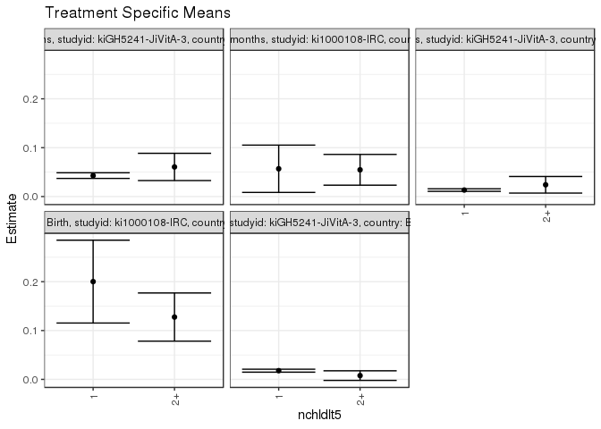

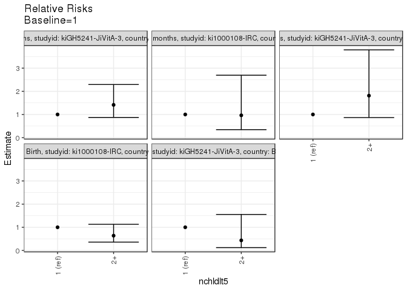

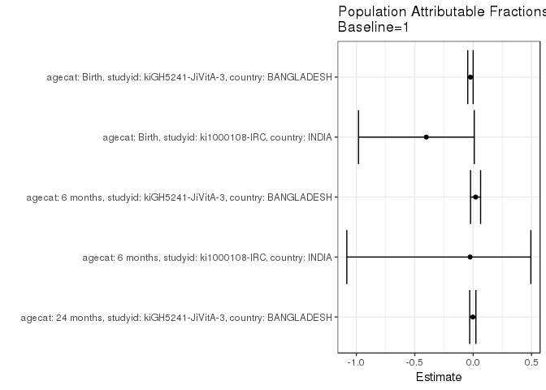

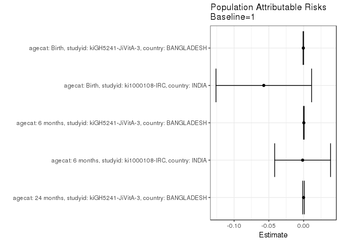

## Results Table

### Parameter: TSM

| agecat | studyid | country | intervention_level | baseline_level | estimate | ci_lower | ci_upper |
| --- | --- | --- | --- | --- | --- | --- | --- |
| Birth | ki1000108-IRC | INDIA | 1 | NA | 0.2001490 | 0.1153354 | 0.2849627 |
| Birth | ki1000108-IRC | INDIA | 2+ | NA | 0.1275548 | 0.0782482 | 0.1768615 |
| Birth | kiGH5241-JiVitA-3 | BANGLADESH | 1 | NA | 0.0177962 | 0.0147648 | 0.0208277 |
| Birth | kiGH5241-JiVitA-3 | BANGLADESH | 2+ | NA | 0.0077320 | -0.0020978 | 0.0175618 |
| 6 months | ki1000108-IRC | INDIA | 1 | NA | 0.0568182 | 0.0083674 | 0.1052690 |
| 6 months | ki1000108-IRC | INDIA | 2+ | NA | 0.0547264 | 0.0232286 | 0.0862241 |
| 6 months | kiGH5241-JiVitA-3 | BANGLADESH | 1 | NA | 0.0132617 | 0.0106563 | 0.0158670 |
| 6 months | kiGH5241-JiVitA-3 | BANGLADESH | 2+ | NA | 0.0240362 | 0.0070298 | 0.0410425 |
| 24 months | kiGH5241-JiVitA-3 | BANGLADESH | 1 | NA | 0.0428369 | 0.0370498 | 0.0486240 |
| 24 months | kiGH5241-JiVitA-3 | BANGLADESH | 2+ | NA | 0.0605726 | 0.0326780 | 0.0884672 |

### Parameter: E(Y)

| agecat | studyid | country | intervention_level | baseline_level | estimate | ci_lower | ci_upper |
| --- | --- | --- | --- | --- | --- | --- | --- |
| Birth | ki1000108-IRC | INDIA | NA | NA | 0.1428571 | 0.0989504 | 0.1867638 |
| Birth | kiGH5241-JiVitA-3 | BANGLADESH | NA | NA | 0.0173966 | 0.0144432 | 0.0203501 |
| 6 months | ki1000108-IRC | INDIA | NA | NA | 0.0553633 | 0.0289517 | 0.0817750 |
| 6 months | kiGH5241-JiVitA-3 | BANGLADESH | NA | NA | 0.0135533 | 0.0109751 | 0.0161315 |
| 24 months | kiGH5241-JiVitA-3 | BANGLADESH | NA | NA | 0.0427229 | 0.0370835 | 0.0483623 |

### Parameter: RR

| agecat | studyid | country | intervention_level | baseline_level | estimate | ci_lower | ci_upper |
| --- | --- | --- | --- | --- | --- | --- | --- |
| Birth | ki1000108-IRC | INDIA | 1 | 1 | 1.0000000 | 1.0000000 | 1.000000 |
| Birth | ki1000108-IRC | INDIA | 2+ | 1 | 0.6372993 | 0.3598969 | 1.128519 |
| Birth | kiGH5241-JiVitA-3 | BANGLADESH | 1 | 1 | 1.0000000 | 1.0000000 | 1.000000 |
| Birth | kiGH5241-JiVitA-3 | BANGLADESH | 2+ | 1 | 0.4344713 | 0.1214073 | 1.554810 |
| 6 months | ki1000108-IRC | INDIA | 1 | 1 | 1.0000000 | 1.0000000 | 1.000000 |
| 6 months | ki1000108-IRC | INDIA | 2+ | 1 | 0.9631841 | 0.3442791 | 2.694685 |
| 6 months | kiGH5241-JiVitA-3 | BANGLADESH | 1 | 1 | 1.0000000 | 1.0000000 | 1.000000 |
| 6 months | kiGH5241-JiVitA-3 | BANGLADESH | 2+ | 1 | 1.8124562 | 0.8673766 | 3.787279 |
| 24 months | kiGH5241-JiVitA-3 | BANGLADESH | 1 | 1 | 1.0000000 | 1.0000000 | 1.000000 |
| 24 months | kiGH5241-JiVitA-3 | BANGLADESH | 2+ | 1 | 1.4140271 | 0.8714353 | 2.294459 |

### Parameter: PAR

| agecat | studyid | country | intervention_level | baseline_level | estimate | ci_lower | ci_upper |
| --- | --- | --- | --- | --- | --- | --- | --- |
| Birth | ki1000108-IRC | INDIA | 1 | NA | -0.0572919 | -0.1260269 | 0.0114431 |
| Birth | kiGH5241-JiVitA-3 | BANGLADESH | 1 | NA | -0.0003996 | -0.0008055 | 0.0000063 |
| 6 months | ki1000108-IRC | INDIA | 1 | NA | -0.0014549 | -0.0416475 | 0.0387378 |
| 6 months | kiGH5241-JiVitA-3 | BANGLADESH | 1 | NA | 0.0002916 | -0.0002922 | 0.0008755 |
| 24 months | kiGH5241-JiVitA-3 | BANGLADESH | 1 | NA | -0.0001140 | -0.0012452 | 0.0010172 |

### Parameter: PAF

| agecat | studyid | country | intervention_level | baseline_level | estimate | ci_lower | ci_upper |
| --- | --- | --- | --- | --- | --- | --- | --- |
| Birth | ki1000108-IRC | INDIA | 1 | NA | -0.4010433 | -0.9817934 | 0.0095223 |
| Birth | kiGH5241-JiVitA-3 | BANGLADESH | 1 | NA | -0.0229703 | -0.0463990 | -0.0000661 |
| 6 months | ki1000108-IRC | INDIA | 1 | NA | -0.0262784 | -1.0818073 | 0.4940707 |
| 6 months | kiGH5241-JiVitA-3 | BANGLADESH | 1 | NA | 0.0215170 | -0.0224442 | 0.0635880 |
| 24 months | kiGH5241-JiVitA-3 | BANGLADESH | 1 | NA | -0.0026685 | -0.0294886 | 0.0234529 |